# Natural Language Processing - Twitter Analysis

## Problem Statement

### Context

Twitter's massive user base of 330 million monthly active users presents a direct avenue for businesses to connect with a broad audience. However, the vast amount of information on the platform makes it challenging for brands to swiftly detect negative social mentions that may impact their reputation. To tackle this, sentiment analysis has become a crucial tool in social media marketing, enabling businesses to monitor emotions in conversations, understand customer sentiments, and gain insights to stay ahead in their industry.

That's why sentiment analysis/classification, which involves monitoring emotions in conversations on social media platforms, has become a key strategy in social media marketing.

### Objective

The aim of this project is to build a sentimental analysis model that classify the sentiment of tweets into the positive, neutral & negative.

### Data Dictionary

- tweet_id - A unique identifier for each tweet
- airline_sentiment - The sentiment label of the tweet, such as positive, negative, or neutral
- airline_sentiment_confidence - The confidence level associated with the sentiment label
- negativereason - A category indicating the reason for negative sentiment
- negativereason_confidence - The confidence level associated with the negative reason  
  *airline - The airline associated with the tweet
- airline_sentiment_gold - Gold standard sentiment label
- name - The username of the tweet author
- retweet_count - The number of times the tweet has been retweeted
- text - The actual text content of the tweet.
- tweet_coord - Coordinates of the tweet
- tweet_created - The timestamp when the tweet was created
- tweet_location - The location mentioned in the tweet
- user_timezone - The timezone of the tweet author

## Importing necessary libraries

```python
# libraries for data manupulation and data reading
import numpy as np
import pandas as pd

# libraries for data reading
import matplotlib.pyplot as plt
import seaborn as sns

# Library for splitting the data
from sklearn.model_selection import train_test_split

# Library for creating model and finding the score
from sklearn.ensemble import RandomForestClassifier
from sklearn.model_selection import cross_val_score

# For text pre processing
import re
import nltk
from nltk.corpus import stopwords
from nltk.tokenize import word_tokenize, sent_tokenize
from nltk.stem.wordnet import WordNetLemmatizer
from bs4 import BeautifulSoup
import contractions

# For Vectorization (Converting text data to numbers).
from sklearn.feature_extraction.text import CountVectorizer
from sklearn.feature_extraction.text import TfidfVectorizer

# For creating word cloud
from wordcloud import WordCloud

# For creating confusion matrix
from sklearn.metrics import confusion_matrix

# Remove warning
import warnings
warnings.filterwarnings('ignore')
```

```python
nltk.download('punkt', quiet=True)
nltk.download('stopwords', quiet=True)
nltk.download('wordnet', quiet=True)
```

```
True
```

## Loading the dataset

```python
# Loading the dataset
tweets_df = pd.read_csv("C:/Users/abhis/Downloads/Tweets.csv")
```

```python
# read the data
tweets_df.head()
```

|  | tweet_id | airline_sentiment | airline_sentiment_confidence | negativereason | negativereason_confidence | airline | airline_sentiment_gold | name | negativereason_gold | retweet_count | text | tweet_coord | tweet_created | tweet_location | user_timezone |
| --- | --- | --- | --- | --- | --- | --- | --- | --- | --- | --- | --- | --- | --- | --- | --- |
| 0 | 570306133677760513 | neutral | 1.0000 | NaN | NaN | Virgin America | NaN | cairdin | NaN | 0 | @VirginAmerica What @dhepburn said. | NaN | 2015-02-24 11:35:52 -0800 | NaN | Eastern Time (US & Canada) |
| 1 | 570301130888122368 | positive | 0.3486 | NaN | 0.0000 | Virgin America | NaN | jnardino | NaN | 0 | @VirginAmerica plus you've added commercials t... | NaN | 2015-02-24 11:15:59 -0800 | NaN | Pacific Time (US & Canada) |
| 2 | 570301083672813571 | neutral | 0.6837 | NaN | NaN | Virgin America | NaN | yvonnalynn | NaN | 0 | @VirginAmerica I didn't today... Must mean I n... | NaN | 2015-02-24 11:15:48 -0800 | Lets Play | Central Time (US & Canada) |
| 3 | 570301031407624196 | negative | 1.0000 | Bad Flight | 0.7033 | Virgin America | NaN | jnardino | NaN | 0 | @VirginAmerica it's really aggressive to blast... | NaN | 2015-02-24 11:15:36 -0800 | NaN | Pacific Time (US & Canada) |
| 4 | 570300817074462722 | negative | 1.0000 | Can't Tell | 1.0000 | Virgin America | NaN | jnardino | NaN | 0 | @VirginAmerica and it's a really big bad thing... | NaN | 2015-02-24 11:14:45 -0800 | NaN | Pacific Time (US & Canada) |

## Data Overview

The initial steps to get an overview of any dataset is to:

- Observe the first few rows of the dataset, to check whether the dataset has been loaded properly or not
- Get information about the number of rows and columns in the dataset
- Find out the data types of the columns to ensure that data is stored in the preferred format and the value of each property is as expected.

```python
tweets_df.head()
```

|  | tweet_id | airline_sentiment | airline_sentiment_confidence | negativereason | negativereason_confidence | airline | airline_sentiment_gold | name | negativereason_gold | retweet_count | text | tweet_coord | tweet_created | tweet_location | user_timezone |
| --- | --- | --- | --- | --- | --- | --- | --- | --- | --- | --- | --- | --- | --- | --- | --- |
| 0 | 570306133677760513 | neutral | 1.0000 | NaN | NaN | Virgin America | NaN | cairdin | NaN | 0 | @VirginAmerica What @dhepburn said. | NaN | 2015-02-24 11:35:52 -0800 | NaN | Eastern Time (US & Canada) |
| 1 | 570301130888122368 | positive | 0.3486 | NaN | 0.0000 | Virgin America | NaN | jnardino | NaN | 0 | @VirginAmerica plus you've added commercials t... | NaN | 2015-02-24 11:15:59 -0800 | NaN | Pacific Time (US & Canada) |
| 2 | 570301083672813571 | neutral | 0.6837 | NaN | NaN | Virgin America | NaN | yvonnalynn | NaN | 0 | @VirginAmerica I didn't today... Must mean I n... | NaN | 2015-02-24 11:15:48 -0800 | Lets Play | Central Time (US & Canada) |
| 3 | 570301031407624196 | negative | 1.0000 | Bad Flight | 0.7033 | Virgin America | NaN | jnardino | NaN | 0 | @VirginAmerica it's really aggressive to blast... | NaN | 2015-02-24 11:15:36 -0800 | NaN | Pacific Time (US & Canada) |
| 4 | 570300817074462722 | negative | 1.0000 | Can't Tell | 1.0000 | Virgin America | NaN | jnardino | NaN | 0 | @VirginAmerica and it's a really big bad thing... | NaN | 2015-02-24 11:14:45 -0800 | NaN | Pacific Time (US & Canada) |

```python
# Shape of the data
print(f"There are {tweets_df.shape[0]} rows and {tweets_df.shape[1]} columns.")
```

```
There are 14640 rows and 15 columns.
```

```python
tweets_df.info()
```

```
<class 'pandas.core.frame.DataFrame'>
RangeIndex: 14640 entries, 0 to 14639
Data columns (total 15 columns):
 #   Column                        Non-Null Count  Dtype
---  ------                        --------------  -----
 0   tweet_id                      14640 non-null  int64
 1   airline_sentiment             14640 non-null  object
 2   airline_sentiment_confidence  14640 non-null  float64
 3   negativereason                9178 non-null   object
 4   negativereason_confidence     10522 non-null  float64
 5   airline                       14640 non-null  object
 6   airline_sentiment_gold        40 non-null     object
 7   name                          14640 non-null  object
 8   negativereason_gold           32 non-null     object
 9   retweet_count                 14640 non-null  int64
 10  text                          14640 non-null  object
 11  tweet_coord                   1019 non-null   object
 12  tweet_created                 14640 non-null  object
 13  tweet_location                9907 non-null   object
 14  user_timezone                 9820 non-null   object
dtypes: float64(2), int64(2), object(11)
memory usage: 1.7+ MB
```

There are 2 float column and 2 int column and 11 object column.

```python
tweets_df.describe().transpose()
```

|  | count | mean | std | min | 25% | 50% | 75% | max |
| --- | --- | --- | --- | --- | --- | --- | --- | --- |
| tweet_id | 14640.0 | 5.692184e+17 | 7.791112e+14 | 5.675883e+17 | 5.685592e+17 | 5.694779e+17 | 5.698905e+17 | 5.703106e+17 |
| airline_sentiment_confidence | 14640.0 | 9.001689e-01 | 1.628300e-01 | 3.350000e-01 | 6.923000e-01 | 1.000000e+00 | 1.000000e+00 | 1.000000e+00 |
| negativereason_confidence | 10522.0 | 6.382983e-01 | 3.304398e-01 | 0.000000e+00 | 3.606000e-01 | 6.706000e-01 | 1.000000e+00 | 1.000000e+00 |
| retweet_count | 14640.0 | 8.265027e-02 | 7.457782e-01 | 0.000000e+00 | 0.000000e+00 | 0.000000e+00 | 0.000000e+00 | 4.400000e+01 |

```python
tweets_df.isnull().sum()
```

```
tweet_id                            0
airline_sentiment                   0
airline_sentiment_confidence        0
negativereason                   5462
negativereason_confidence        4118
airline                             0
airline_sentiment_gold          14600
name                                0
negativereason_gold             14608
retweet_count                       0
text                                0
tweet_coord                     13621
tweet_created                       0
tweet_location                   4733
user_timezone                    4820
dtype: int64
```

There are a lot of null values present in negativereason, negativereason_confidence, airline_sentiment_gold, negativereason_gold, tweet_coord, tweet_location, user_timezone.

```python
tweets_df.duplicated().sum()
```

```
36
```

There are 36 duplicate values.

## Exploratory Data Analysis

- EDA is an important part of any project involving data.
- It is important to investigate and understand the data better before building a model with it.
- A few questions have been mentioned below which will help you approach the analysis in the right manner and generate insights from the data.
- A thorough analysis of the data, in addition to the questions mentioned below, should be done.

**Questions**:

- What is the percentage of tweets for each airline?
- What is the distribution of sentiments across all the tweets?
- What is the distribution of sentiments for each airline?
- What does the plot of negative reasons indicate?
- How does a wordcloud appear for negative tweets?
- How does a wordcloud appear for positive tweets?
- What are insights observed from EDA?

```python
# Creating function for the barplot for categorical columns.

def cat_barplot(data_frame, column, display_percentage=False):
    total_entries = len(data_frame[column])

    plt.figure(figsize=(len(data_frame[column].unique()) + 2, 6))
    plt.xticks(rotation=90, fontsize=15)

    ax = sns.countplot(
        data=data_frame,
        x=column,
        color="skyblue",
        legend=False
    )

    for patch in ax.patches:
        if display_percentage:
            label = "{:.1f}%".format(100 * patch.get_height() / total_entries)
        else:
            label = patch.get_height()

        x_position = patch.get_x() + patch.get_width() / 2
        y_position = patch.get_height()

        ax.annotate(
            label,
            (x_position, y_position),
            ha="center",
            va="center",
            size=12,
            xytext=(0, 5),
            textcoords="offset points",
        )

    plt.show()
```

#### What is the percentage of tweets for each airline?

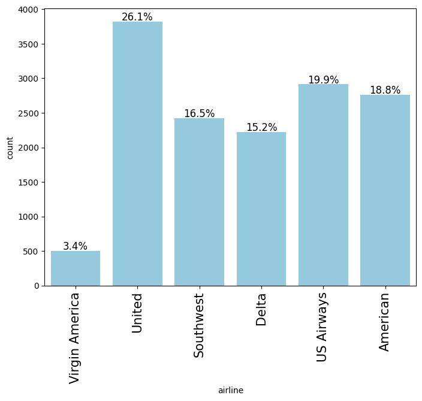

```python
cat_barplot(tweets_df, "airline", display_percentage=True)
```

The Unities airlines has the most percentage of tweets, followed by US Airways and American airlines. We can also see that Virgin Americal has the lowest percentage.

#### What is the distribution of sentiments across all the tweets?

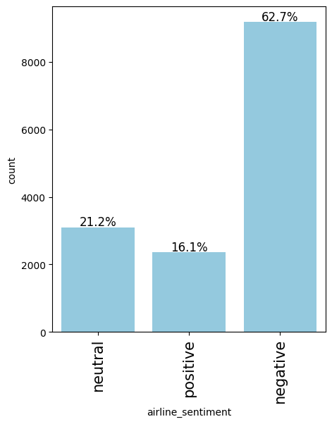

```python
cat_barplot(tweets_df, "airline_sentiment", display_percentage=True)
```

The percentange of negative tweets is the hightes followed by neutral and then positive.

#### What is the distribution of sentiments for each airline?

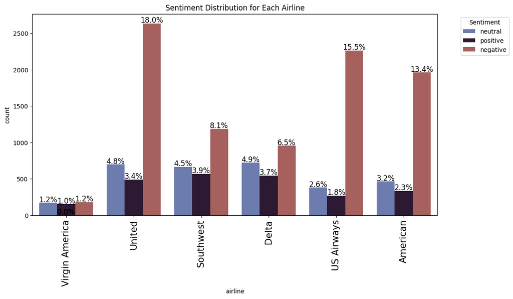

```python
plt.figure(figsize=(len(tweets_df['airline'].unique()) * 2, 6))
plt.xticks(rotation=90, fontsize=15)

ax = sns.countplot(data=tweets_df, x='airline', hue='airline_sentiment', palette='twilight')

total_entries = len(tweets_df['airline'])
for patch in ax.patches:
    percentage = 100 * patch.get_height() / total_entries
    label = "{:.1f}%".format(percentage)
    ax.annotate(label, (patch.get_x() + patch.get_width() / 2, patch.get_height()),
                ha="center", va="center", size=12, xytext=(0, 5), textcoords="offset points")

plt.legend(title='Sentiment', bbox_to_anchor=(1.05, 1), loc='upper left')
plt.title('Sentiment Distribution for Each Airline')
plt.show()
```

We can observe that the United airline has the highest nuymber of tweets. But in all the airlines the negative tweets are the most. After negative tweets the neutral tweets are the second most and then the positive tweets are the least.

#### What does the plot of negative reasons indicate?

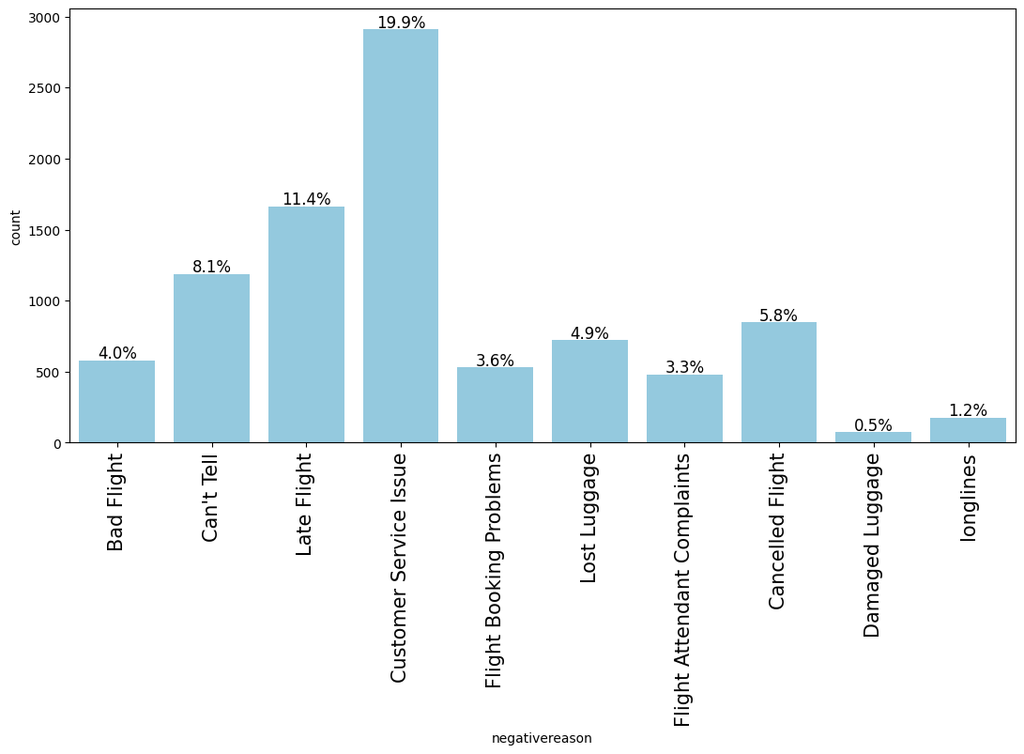

```python
cat_barplot(tweets_df, "negativereason", display_percentage=True)
```

The most negative reasons are given to Customer services then followed by late flight and then the next most reason was that the people cannot tell. The damaged lugage and the longliness are the least issue people faced.

#### How does a wordcloud appear for negative tweets?

```python
negative_tweets = tweets_df[tweets_df['airline_sentiment'] == 'negative']
```

```python
negative_reasons_data = ' '.join(negative_tweets['text'].astype(str))
```

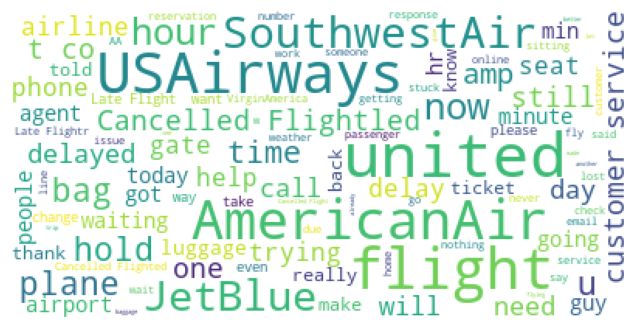

```python
wordcloud = WordCloud(max_font_size = 40, max_words=100, background_color="white").generate(negative_reasons_data)
plt.figure(figsize=(8,12))
plt.imshow(wordcloud)
plt.axis("off")
plt.show()
```

#### How does a wordcloud appear for positive tweets?

```python
positive_tweets = tweets_df[tweets_df['airline_sentiment'] == 'positive']
```

```python
positive_reasons_data = ' '.join(positive_tweets['text'].astype(str))
```

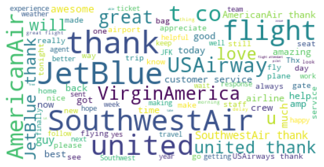

```python
wordcloud_positive = WordCloud(max_font_size = 40, max_words=100, background_color="white").generate(positive_reasons_data)
plt.figure(figsize=(8,12))
plt.imshow(wordcloud_positive)
plt.axis("off")
plt.show()
```

#### What are insights observed from EDA?

- The Unities airlines has the most percentage of tweets, followed by US Airways and American airlines. We can also see that Virgin Americal has the lowest percentage.
- The percentange of negative tweets is the hightes followed by neutral and then positive.
- We can observe that the United airline has the highest nuymber of tweets. But in all the airlines the negative tweets are the most. After negative tweets the neutral tweets are the second most and then the positive tweets are the least.
- The most negative reasons are given to Customer services then followed by late flight and then the next most reason was that the people cannot tell. The damaged lugage and the longliness are the least issue people faced.
- From the negative cloud image we can observe that the word like delay and customer service is appearing which is the cause of the negative comments and the word united and US Airways has been shown a lot which also confirms with the data that US Airways and united airlines has the most negative comments.

## Data Preparation for Modeling

- Drop all unnecessary columns
- Remove html tags
- Replace contractions in string(e.g. replace I'm --> I am) and so on.\
- Remove numbers
- Tokenization
- To remove Stopwords
- Lemmatized data

```python
data = tweets_df.copy()
```

#### Drop all unnecessary columns

##### Understanding the columns

Removing all the column expect the airline_sentiment and the text because these two columns are only needed to build a sentimental analysis model that classify the sentiment of tweets into the positive, neutral & negative.

```python
model_columns = ['text', 'airline_sentiment']
tweets_model_data = data[model_columns]
```

```python
tweets_model_data.head()
```

|  | text | airline_sentiment |
| --- | --- | --- |
| 0 | @VirginAmerica What @dhepburn said. | neutral |
| 1 | @VirginAmerica plus you've added commercials t... | positive |
| 2 | @VirginAmerica I didn't today... Must mean I n... | neutral |
| 3 | @VirginAmerica it's really aggressive to blast... | negative |
| 4 | @VirginAmerica and it's a really big bad thing... | negative |

```python
tweets_model_data.isnull().sum()
```

```
text                 0
airline_sentiment    0
dtype: int64
```

No null value in data.

```python
tweets_model_data.duplicated().sum()
```

```
188
```

There are some duplicate values in the data.

```python
tweets_model_data.drop_duplicates(inplace=True)
tweets_model_data.reset_index(inplace=True,drop='first')
```

##### Checking the shape of the data

```python
tweets_model_data.shape
```

```
(14452, 2)
```

```python
unique_sentiments = tweets_model_data['airline_sentiment'].unique()

print("Unique Sentiments:", unique_sentiments)
```

```
Unique Sentiments: ['neutral' 'positive' 'negative']
```

#### Remove html tags

```python
tweets_model_data['text'] = tweets_model_data['text'].apply(
    lambda x: BeautifulSoup(x, 'html.parser').get_text()
)
```

```python
tweets_model_data.head()
```

|  | text | airline_sentiment |
| --- | --- | --- |
| 0 | @VirginAmerica What @dhepburn said. | neutral |
| 1 | @VirginAmerica plus you've added commercials t... | positive |
| 2 | @VirginAmerica I didn't today... Must mean I n... | neutral |
| 3 | @VirginAmerica it's really aggressive to blast... | negative |
| 4 | @VirginAmerica and it's a really big bad thing... | negative |

#### Replace contractions in string(e.g. replace I'm --> I am) and so on.\

```python
tweets_model_data['text'] = tweets_model_data['text'].apply(contractions.fix)
```

```python
tweets_model_data.head()
```

|  | text | airline_sentiment |
| --- | --- | --- |
| 0 | @VirginAmerica What @dhepburn said. | neutral |
| 1 | @VirginAmerica plus you have added commercials... | positive |
| 2 | @VirginAmerica I did not today... Must mean I ... | neutral |
| 3 | @VirginAmerica it is really aggressive to blas... | negative |
| 4 | @VirginAmerica and it is a really big bad thin... | negative |

#### Remove numbers, Special Characters and Punctuations

```python
tweets_model_data['text'] = tweets_model_data['text'].apply(
    lambda x: re.sub("[^a-zA-Z]", " ", x)
)
```

```python
tweets_model_data.head()
```

|  | text | airline_sentiment |
| --- | --- | --- |
| 0 | VirginAmerica What dhepburn said | neutral |
| 1 | VirginAmerica plus you have added commercials... | positive |
| 2 | VirginAmerica I did not today Must mean I ... | neutral |
| 3 | VirginAmerica it is really aggressive to blas... | negative |
| 4 | VirginAmerica and it is a really big bad thin... | negative |

#### Conversion to lowercase

```python
tweets_model_data['text'] = tweets_model_data['text'].str.lower()
```

```python
tweets_model_data.head()
```

|  | text | airline_sentiment |
| --- | --- | --- |
| 0 | virginamerica what dhepburn said | neutral |
| 1 | virginamerica plus you have added commercials... | positive |
| 2 | virginamerica i did not today must mean i ... | neutral |
| 3 | virginamerica it is really aggressive to blas... | negative |
| 4 | virginamerica and it is a really big bad thin... | negative |

#### Tokenization

```python
tweets_model_data['text'] = tweets_model_data['text'].apply(word_tokenize)
```

```python
tweets_model_data.head()
```

|  | text | airline_sentiment |
| --- | --- | --- |
| 0 | [virginamerica, what, dhepburn, said] | neutral |
| 1 | [virginamerica, plus, you, have, added, commer... | positive |
| 2 | [virginamerica, i, did, not, today, must, mean... | neutral |
| 3 | [virginamerica, it, is, really, aggressive, to... | negative |
| 4 | [virginamerica, and, it, is, a, really, big, b... | negative |

#### To remove Stopwords

```python
stop_words = set(stopwords.words('english'))
tweets_model_data['text'] = tweets_model_data['text'].apply(
    lambda x: [word for word in x if word.lower() not in stop_words]
)
```

```python
tweets_model_data.head()
```

|  | text | airline_sentiment |
| --- | --- | --- |
| 0 | [virginamerica, dhepburn, said] | neutral |
| 1 | [virginamerica, plus, added, commercials, expe... | positive |
| 2 | [virginamerica, today, must, mean, need, take,... | neutral |
| 3 | [virginamerica, really, aggressive, blast, obn... | negative |
| 4 | [virginamerica, really, big, bad, thing] | negative |

#### Lemmatized data

```python
lemmatizer = WordNetLemmatizer()
tweets_model_data['text'] = tweets_model_data['text'].apply(
    lambda x: [lemmatizer.lemmatize(word,pos='v') for word in x]
)
```

```python
tweets_model_data.head()
```

|  | text | airline_sentiment |
| --- | --- | --- |
| 0 | [virginamerica, dhepburn, say] | neutral |
| 1 | [virginamerica, plus, add, commercials, experi... | positive |
| 2 | [virginamerica, today, must, mean, need, take,... | neutral |
| 3 | [virginamerica, really, aggressive, blast, obn... | negative |
| 4 | [virginamerica, really, big, bad, thing] | negative |

#### Joining the text.

```python
tweets_model_data['text'] = tweets_model_data['text'].apply(lambda x: ' '.join(x))
```

Lets see the data now.

```python
tweets_model_data.head()
```

|  | text | airline_sentiment |
| --- | --- | --- |
| 0 | virginamerica dhepburn say | neutral |
| 1 | virginamerica plus add commercials experience ... | positive |
| 2 | virginamerica today must mean need take anothe... | neutral |
| 3 | virginamerica really aggressive blast obnoxiou... | negative |
| 4 | virginamerica really big bad thing | negative |

## Model Building

### Using countvectorizer

- Intialize countvectorizer and use it for vectorization
- Store Independent and Dependent variables
- Split the data into train and test
- Build a Random Forest model on train data
- Use Cross validation to validate the score and to find optimal n_estimators
- Plot the misclassification error for each of estimators
- Test the model on testing data
- Plot the Confusion matrix plot word cloud for top 20 important features obtained from Count vectorizer and random forest model

##### Intialize countvectorizer and use it for vectorization

```python
max_word_features = 3000

cv_word_vectorizer = CountVectorizer(max_features=max_word_features)
cv_data_features = cv_word_vectorizer.fit_transform(tweets_model_data['text'])
cv_data_features_array = cv_data_features.toarray()
```

```python
cv_data_features_array.shape
```

```
(14452, 3000)
```

##### Store Independent and Dependent variables

```python
X_cv = cv_data_features_array
y_cv = tweets_model_data.airline_sentiment
```

##### Split the data into train and test

```python
X_train_cv, X_test_cv, y_train_cv, y_test_cv = train_test_split(X_cv, y_cv, test_size = 0.2, shuffle = False)
```

##### Build a Random Forest model on train data

```python
rfc = RandomForestClassifier(n_estimators = 150, random_state=42)

rfc.fit(X_train_cv, y_train_cv)
```

```
RandomForestClassifier(n_estimators=150, random_state=42)
```

```python
score = cross_val_score(rfc, X_cv, y_cv, cv=5, scoring='accuracy')
```

```python
print(np.mean(score))
```

```
0.6965078354372658
```

##### Using Cross validation to validate the score and to find optimal n_estimators.

```python
range_of_estimator = [50, 100, 150, 200]
cv_scores = []

for n in range_of_estimator:
    rf_model = RandomForestClassifier(n_estimators=n, random_state=42)
    score = cross_val_score(rf_model, X_cv, y_cv, cv=5, scoring='accuracy')
    cv_scores.append(score.mean())
```

##### Plot the misclassification error for each of estimators

```python
cv_err = [1 - accur for accur in cv_scores]
```

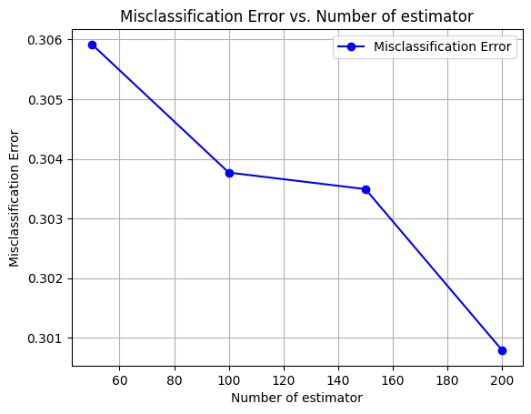

```python
plt.plot(range_of_estimator, cv_err, marker='o', linestyle='-', color='b', label='Misclassification Error')

plt.xlabel("Number of estimator")
plt.ylabel("Misclassification Error")
plt.title("Misclassification Error vs. Number of estimator")
plt.legend()
plt.grid(True)
plt.show()
```

```python
optimal_estimator = range_of_estimator[cv_err.index(min(cv_err))]
optimal_estimator
```

```
200
```

##### Test the model on testing data

```python
rfc_cv = RandomForestClassifier(n_estimators = optimal_estimator)
rfc_cv.fit(X_train_cv, y_train_cv)
rfc_cv.score(X_test_cv, y_test_cv)
```

```
0.8038740920096852
```

##### We can now see the the score has been increased by using the estimator 200 that is the optimal estimator.

```python
prediction_cv =  rfc_cv.predict(X_test_cv)
```

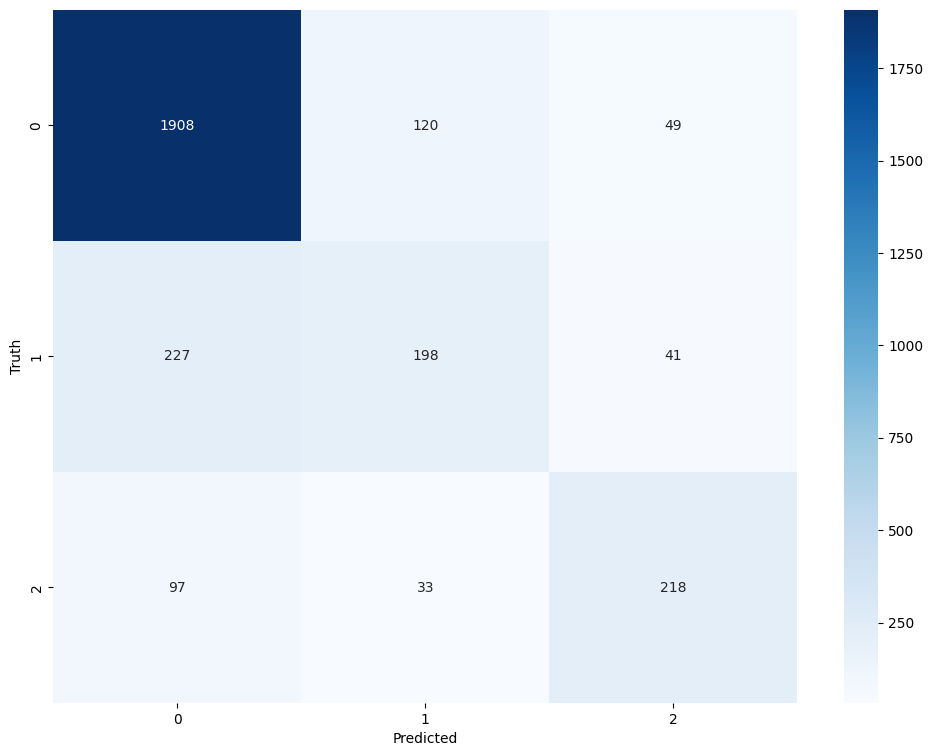

```python
cm_cv=confusion_matrix(y_test_cv,prediction_cv)

plt.figure(figsize=(12,9))
sns.heatmap(cm_cv, annot=True, fmt='d', cmap='Blues')
plt.xlabel('Predicted')
plt.ylabel('Truth')
plt.show()
```

##### Plot the Confusion matrix plot word cloud for top 20 important features obtained from Count vectorizer and random forest model

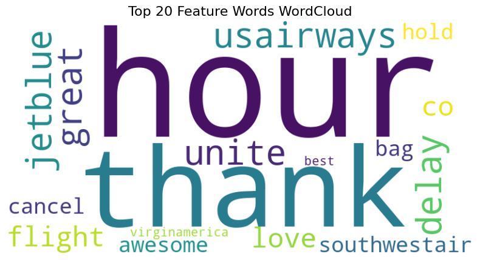

```python
cv_features = cv_word_vectorizer.get_feature_names_out()
cv_feature=rfc_cv.feature_importances_
cv_sorted_features = np.argsort(cv_feature)[::-1]

cv_top_feature = ''

for idx in cv_sorted_features[:20]:
    cv_top_feature += cv_features[idx]
    cv_top_feature += ' '

wordcloud = WordCloud(
    background_color="white",
    colormap='viridis',
    width=800,
    height=400
).generate(cv_top_feature)

plt.figure(figsize=(10, 5))
plt.imshow(wordcloud, interpolation='bilinear')
plt.title('Top 20 Feature Words WordCloud', fontsize=16)
plt.axis("off")
plt.show()
```

##### Top 20 features

```python
cv_top_feature
```

```
'thank usairways delay jetblue great unite flight love co southwestair http hold hours awesome bag get cancel virginamerica hour best '
```

### Using TF-IDF (Term Frequency- Inverse Document Frequency)

- Intialize TFIDF and use it for vectorization
- Store Independent and Dependent variables
- Split the data into train and test
- Build a Random Forest model on train data
- Use Cross validation to validate the score and to find optimal n_estimators
- Plot the misclassification error for each of estimators
- Test the model on testing data
- Plot the Confusion matrix plot word cloud for top 20 important features obtained from TFIDF and random forest model

##### Intialize TFIDF and use it for vectorization

```python
max_feature_limit = 3000
tf_word_vectorizer = TfidfVectorizer(max_features=max_feature_limit)
tf_data_features = tf_word_vectorizer.fit_transform(tweets_model_data['text'])

tf_data_features_array = tf_data_features.toarray()
```

```python
tf_data_features_array.shape
```

```
(14452, 3000)
```

##### Store Independent and Dependent variables

```python
X_tf = tf_data_features_array
y_tf = tweets_model_data.airline_sentiment
```

##### Split the data into train and test

```python
X_train_tf, X_test_tf, y_train_tf, y_test_tf = train_test_split(X_tf, y_tf, test_size=0.2, shuffle=False)
```

##### Build a Random Forest model on train data

```python
rfc_tf = RandomForestClassifier(n_estimators = 150, random_state=42)

rfc_tf.fit(X_train_tf, y_train_tf)
```

```
RandomForestClassifier(n_estimators=150, random_state=42)
```

```python
score_tf = cross_val_score(rfc_tf, X_tf, y_tf, cv=5, scoring='accuracy')
```

```python
print(np.mean(score_tf))
```

```
0.696646147990602
```

##### Using Cross validation to validate the score and to find optimal n_estimators

```python
range_of_estimator = [50, 100, 150, 200]
cv_scores_tf = []

for n in range_of_estimator:
    rf_model_tf = RandomForestClassifier(n_estimators=n, random_state=42)
    score = cross_val_score(rf_model_tf, X_tf, y_tf, cv=5, scoring='accuracy')
    cv_scores_tf.append(score.mean())
```

##### Plot the misclassification error for each of estimators

```python
tf_err = [1 - accur for accur in cv_scores_tf]
```

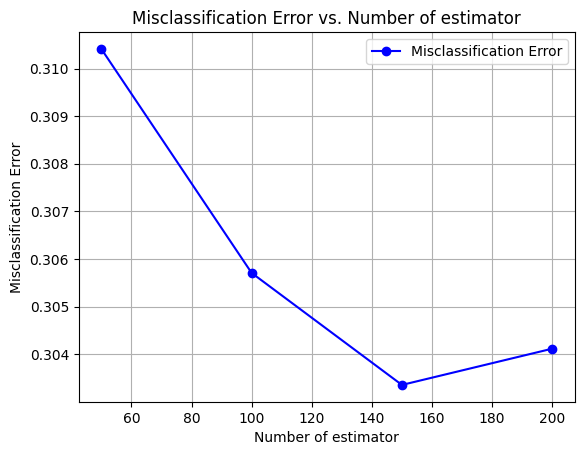

```python
plt.plot(range_of_estimator, tf_err, marker='o', linestyle='-', color='b', label='Misclassification Error')

plt.xlabel("Number of estimator")
plt.ylabel("Misclassification Error")
plt.title("Misclassification Error vs. Number of estimator")
plt.legend()
plt.grid(True)
plt.show()
```

```python
optimal_estimator_tf = range_of_estimator[tf_err.index(min(tf_err))]
optimal_estimator_tf
```

```
150
```

##### Test the model on testing data

```python
rfc_tf = RandomForestClassifier(n_estimators = optimal_estimator_tf)
rfc_tf.fit(X_train_tf, y_train_tf)
rfc_tf.score(X_test_tf, y_test_tf)
```

```
0.7924593566240056
```

##### Plot the Confusion matrix plot word cloud for top 20 important features obtained from TFIDF and random forest model

```python
prediction_tf =  rfc_tf.predict(X_test_tf)
```

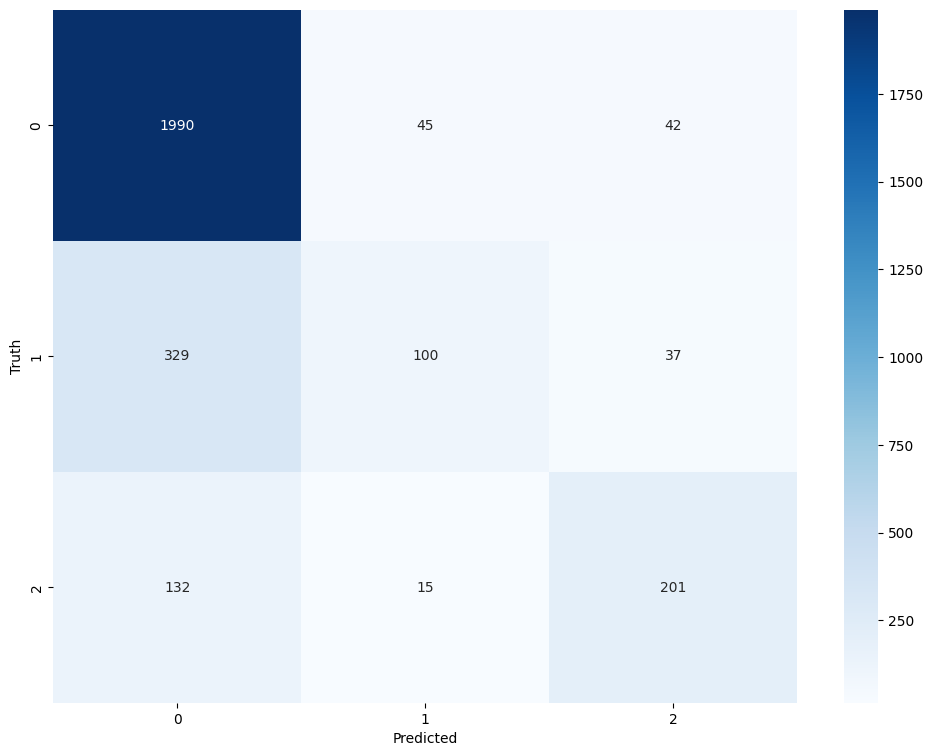

```python
cm_tf=confusion_matrix(y_test_tf,prediction_tf)

plt.figure(figsize=(12,9))
sns.heatmap(cm_tf, annot=True, fmt='d', cmap='Blues')
plt.xlabel('Predicted')
plt.ylabel('Truth')
plt.show()
```

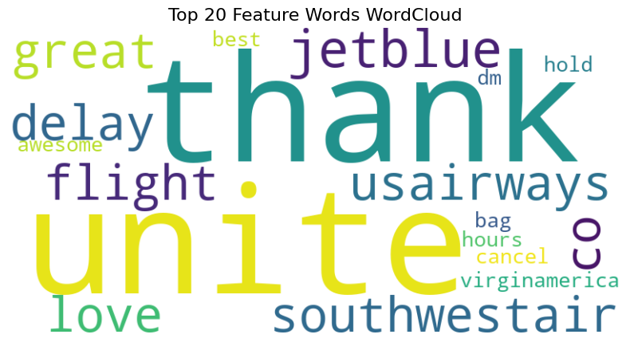

```python
tf_features = tf_word_vectorizer.get_feature_names_out()
feature_tf=rfc_tf.feature_importances_
sorted_features_tf = np.argsort(feature_tf)[::-1]

tf_top_feature = ''

for idx in sorted_features_tf[:20]:
    tf_top_feature += tf_features[idx]
    tf_top_feature += ' '

wordcloud = WordCloud(
    background_color="white",
    colormap='viridis',
    width=800,
    height=400
).generate(tf_top_feature)

plt.figure(figsize=(10, 5))
plt.imshow(wordcloud, interpolation='bilinear')
plt.title('Top 20 Feature Words WordCloud', fontsize=16)
plt.axis("off")
plt.show()
```

##### Top 20 feature

```python
tf_top_feature
```

```
'thank unite jetblue southwestair usairways flight delay great co http love virginamerica get awesome hours hold bag cancel dm best '
```

## Summary

**Conslusion**

**Insights**

- The Unities airlines has the most percentage of tweets, followed by US Airways and American airlines. We can also see that Virgin America has the lowest percentage.
- The percentange of negative tweets is the hightest followed by neutral and then positive.
- We can observe that the United airline has the highest nuymber of tweets. But in all the airlines the negative tweets are the most. After negative tweets the neutral tweets are the second most and then the positive tweets are the least.
- The most negative reasons are given to Customer services then followed by late flight and then the next most reason was that the people cannot tell. The damaged lugage and the longliness are the least issue people faced.
- From the negative cloud image we can observe that the word like delay and customer service is appearing which is the cause of the negative comments and the word united and US Airways has been shown a lot which also confirms with the data that US Airways and united airlines has the most negative comments.